# Visualizing Distributions

This is **Tutorial 5.2** from the ESL course taught at the Faculty of Informatics and Information Technologies, Slovak University of Technology in Bratislava.

The course loosely follows the book *An* *Introduction to Statistical Learning with Applications in R*[^1], while also drawing inspiration from Hadley Wickham’s *Advanced R*[^2]. You may notice small insights borrowed from these two excellent books here and there because they set a remarkably high standard for beginners, and they’re very hard to surpass.

| Version | Last Edit | Changes |
| --- | --- | --- |
| 2026.1 | 15-2-2026 | Minor text edits. |

This tutorial builds directly on the pre‑study material you’re expected to master by the end of week 2 and forms the foundation for the project you’ll tackle later. Study it carefully and complete all practice activities throughout weeks 3–6 to ensure you’re fully prepared.

### Motivation

Analyzing the distribution of roles across national football leagues can provide valuable insights into the composition and dynamics of teams. By examining how different roles are distributed within and across leagues, we can identify patterns and trends that may influence team performance and strategy. For instance, understanding the prevalence of certain roles, such as forwards, midfielders, defenders, and goalkeepers, can help in assessing the tactical approaches favored by different leagues. Additionally, this analysis can reveal how teams balance their line-ups and allocate resources to various positions, which can be crucial for scouting, training, and game planning.

### A Single Categorical Variable

The categorical variable such as <*football league name>* is the type of a variable that takes on a limited set of values. In programming languages like Java, these variables are often declared as *<enum>* types. In R, however, this variable is referred to as a factor, a term originating from statistics. We have covered factors in some of the earlier tutorials, so it is beneficial to review that material before proceeding further.

To show the distribution of a single categorical variable, bar plots are a go-to choice. The height of each bar shows how many observations fall into each category. For instance, you can use bar plots to display the number of players in the top five football leagues in Europe.

This tutorial focuses on the five leagues we care about from the `players_22.csv` file. We’ll also apply `theme_set()` and other local presets for the overall plot visual from **Practicum 5.1**, so we won’t repeat that code here.

### Choosing the Right Geom

We’ll start with a blank canvas and set up `league_name` as one variable in the global aesthetics. To plot the bars, we’ll choose between two geoms: `geom_bar()` or `geom_col()`, each offering a different approach to bar plotting.

|  | `geom_bar()` | `geom_col()` |
| --- | --- | --- |
| **Purpose** | Automatically counts the number of observations in each category and creates a bar plot based on these counts. | Creates a bar plot using the values provided in the data, rather than counting occurrences. |
| **Usage** | Ideal when you want to visualize the frequency distribution of a categorical variable. | Suitable when you already have summary data and want to plot the values directly. |
| **Example** | `ggplot(data, aes(x = League)) + geom_bar()` | `ggplot(data, aes(x = League, y = Count)) + geom_col()` |

The main difference between the two functions is that `geom_bar()` automatically counts the levels of each factor in a tibble column, while with `geom_col()`, you need to calculate these counts yourself using functions like `tally()` or `count()`. A sample input for the function `geom_col()` is shown below.

```r
data %<>%
  filter(league_name %in% c("French Ligue 1", "German 1. Bundesliga",
                            "Spain Primera Division", "Italian Serie A",
                            "English Premier League")) %>%
  count(league_name) %>% # Transform the original data into a table containing counts for each level of a factor.
  rename(League = league_name, Count = n)
```

The `count()` function in this code transforms the wide original data into a long table by summarizing the number of occurrences of each `league_name`. Initially, the data contains multiple columns with various attributes for each player. By using `count(league_name)`, the function groups the data by `league_name` and counts the number of players in each league.

This results in a new table with two columns: `League` (after renaming `league_name`) and `Count` (after remaining `n`), where `Count` represents the count of players in each league.

```
## # A tibble: 5 × 2
##   League                 Count
##   <chr>                  <int>
## 1 English Premier League   652
## 2 French Ligue 1           577
## 3 German 1. Bundesliga     551
## 4 Italian Serie A          563
## 5 Spain Primera Division   633
```

Plugging these data into `geom_col()`, you get a nice bar plot that directly uses the provided values, making it perfect for pre-summarized data. This method ensures that the heights of the bars accurately reflect the counts or values specified in your dataset.

[figure not shown]

```r
data %>%
  ggplot(., aes(x = League, y = Count)) +
  geom_col(fill = "lightgrey")
```

### Refining the Plot Appearance

If you’re in a cheerful mood, why not highlight the bar with a highest count with a different color and add text labels to the bars showing the counts? Just extend the R code with two preprocessing steps and a few additions to the main code.

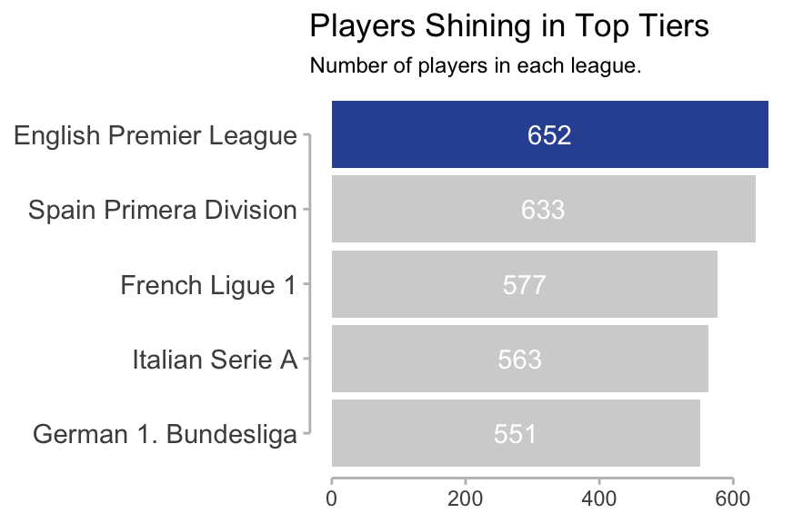

```r
#---- 1. Find the league with the number of players. ----

top.hit <- data %>%
  arrange(desc(Count)) %>%
  slice(1) %>%
  pull(League)

#---- 2. Update and extend the previous code. ----

data %>%
  ggplot(., aes(x = reorder(League,Count), y = Count)) +
  geom_col(aes(fill = League == top.hit), show.legend = FALSE) +
  scale_fill_manual(values = c("TRUE" = "#3153a2", "FALSE" = "lightgrey")) + # Highlight the top league.
  coord_flip() +
  geom_text(aes(label = format(Count)), # Add number of players to each bar.
            colour = "white", position = position_stack(vjust = 0.5)) +
  labs(title = "Players Shining in Top Tiers",
       subtitle = "Number of players in each league.") +
  theme(axis.title.y = element_blank(),
        axis.title.x = element_blank(),
        panel.border = element_blank(),
        axis.line = element_line(colour = "grey"),
        axis.ticks = element_line(color = "grey"),
        axis.text.y = element_text(size = 11),
        plot.subtitle=element_text(size=9)) +
  guides(x = guide_axis(cap = "both"), # Cap both guides.
         y = guide_axis(cap = "both"))
```

The `aes(x = reorder(League, Count))` part of the code reorders the levels of the `League` factor based on the `Count` variable. This means that the leagues will be displayed on the x-axis in order of their counts, from lowest to highest. By reordering the factor levels, the bars in the plot will be arranged according to the number of observations in each league. In addition, the `geom_text()` function adds text labels to each bar in the plot, making it more informative.

### Two Categorical Variables

We can use stacked bar plots to visualize the relationship between two categorical variables. For example, the following two stacked bar plots both display the relationship between `League` and `the proportion of actively playing left-footed footballers`, or specifically, visualizing the distribution of `left-footers`within each island.

The first plot illustrates the proportions of left- and right-footed footballers across five different leagues. While it highlights the frequency of left-footed players in each league, it doesn’t provide a clear understanding of the percentage balance within each league[^3].

```r
#---- 1. Reload data and generate counts for each level of a factor. ----

data %<>%
  filter(league_name %in% c("French Ligue 1", "German 1. Bundesliga",
                            "Spain Primera Division", "Italian Serie A",
                            "English Premier League")) %>%
  count(preferred_foot, league_name) %>%
  rename(League = league_name, Pref_Foot = preferred_foot, Count = n)

data # Print transformed data.
```

```
## # A tibble: 10 × 3
##    Pref_Foot League                 Count
##    <chr>     <chr>                  <int>
##  1 Left      English Premier League   162
##  2 Left      French Ligue 1           151
##  3 Left      German 1. Bundesliga     132
##  4 Left      Italian Serie A          146
##  5 Left      Spain Primera Division   171
##  6 Right     English Premier League   490
##  7 Right     French Ligue 1           426
##  8 Right     German 1. Bundesliga     419
##  9 Right     Italian Serie A          417
## 10 Right     Spain Primera Division   462
```

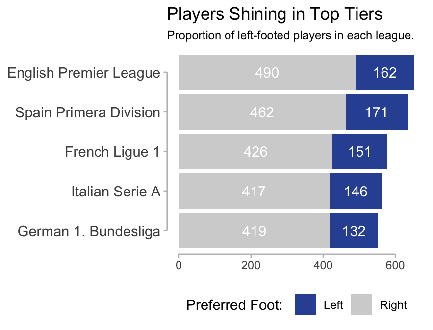

```r
#---- 2. Incorportate two categorical vairables into aesthetics. ----

data %>%
  ggplot(., aes(x = reorder(League,Count), y = Count, fill = Pref_Foot)) +
  geom_col() +
  geom_text(aes(label = format(Count, group = as_factor(Pref_Foot))),
            colour = "white", position = position_stack(vjust = 0.5)) +
  scale_fill_manual(values=c('#3153a2', 'lightgrey')) +
  coord_flip() +
  labs(title = "Players Shining in Top Tiers",
       subtitle = "Proportion of left-footed players in each league.") +
  theme(legend.position="bottom",
        axis.title.y = element_blank(),
        axis.title.x = element_blank(),
        panel.border = element_blank(),
        axis.line = element_line(colour = "grey"),
        axis.ticks = element_line(color = "grey"),
        axis.text.y = element_text(size = 11),
        plot.subtitle=element_text(size=9)) +
  guides(fill = guide_legend(title = "Preferred Foot: "),
         x = guide_axis(cap = "both"), # Cap both ends.
         y = guide_axis(cap = "both"))
```

The second plot, a relative frequency plot created by setting `position = "fill"` in the geom, is particularly useful for comparing the distribution of left-footed players across different football leagues. This approach normalizes the data, making it unaffected by the varying numbers of players in each league. As a result, we can observe that the proportion of left-footed players remains relatively consistent across all leagues.

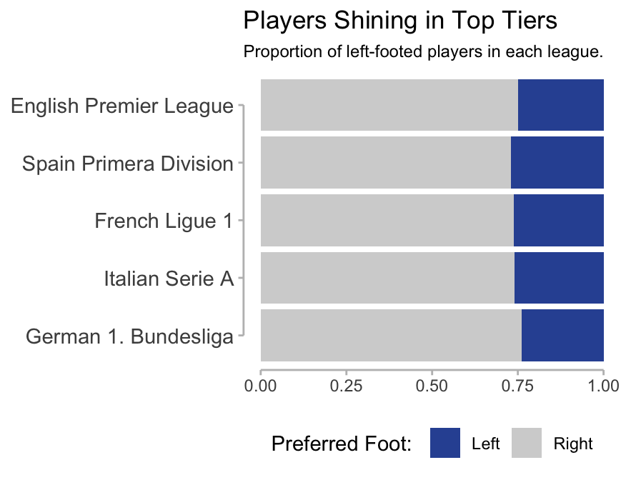

```r
data %>%
  ggplot(., aes(x = reorder(League,Count), y = Count, fill = Pref_Foot)) +
  geom_col(position = "fill") + ...
```

The only downside of this plot is that the proportions are calculated internally, making it difficult to plot them directly. To display these values, it’s recommended to calculate the relative proportions externally by transforming the counts in the `data`. You can then link these numbers with `geom_text()` to add them to the plot.

### A Single Numerical Variable

Another practical application of bar plots is the histogram, which is used for numerical values such as a player’s ball dribbling. **Histograms** represent the skill distribution by dividing the data into bins or intervals and counting the number of players that fall into each bin. The height of each bar indicates the frequency of players within that interval.

In an example below, we will recreate the histogram of players’ `skill_dribbling` by extending the code below and investigate it on different player classes — offensive players, defensive players and midfielders. Since ggplots cannot be natively put into a grid, we will use the patchwork library to get this task done.

To plot the distribution of ball dribbling skills across football players, we’ll use the `geom_histogram()` function on one-dimensional data provided to the aesthetics. However, before doing this, reload the `players_22.csv` file and apply the following code to categorize the players into their respective groups. You might have seen it in previous tutorials, so we will not waste time in explaining its inner workings.

```r
data %<>%
  mutate(role = case_when(str_detect(club_position, "^(CAM|CF|LAM|LF|LS|LW|RAM|RF|RS|RW|ST)$") ~ "Offense",
                          str_detect(club_position, "^(CDM|CM|LCM|LDM|LM|RCM|RDM|RM)$") ~ "Midfielders",
                          str_detect(club_position, "^(CB|LB|LCB|LWB|RB|RCB|RWB)$") ~ "Defense",
                          club_position == "GK" ~ "GK",
                          club_position == "RES" ~ "Reserve",
                          club_position == "SUB" ~ "Substitute",
                          TRUE ~ "Unknown")) %>%
  relocate(c(role, club_position), .after = player_positions) %>%
  filter(!(role %in% c("Unknown", "Reserve", "Substitute")))
```

### Building a Histogram

Next, we apply the `geom_histogram()` function to these data. To focus on specific roles, you can filter the respective players first. However, the fundamental steps for building a histogram plot remain unchanged.

[figure not shown]

```r
data %>%
    ggplot(aes(x = value_eur)) +
    geom_histogram(aes(y = after_stat(density)), colour = "grey", fill = "grey")
```

The `geom_histogram()` function creates a histogram to visualize the distribution of a dataset. The `aes(y = after_stat(density)`[^4]`)` aesthetic maps the y-axis to the density of the data, normalizing the histogram so that the area under the histogram equals 1, which is useful for comparing distributions.

### Adding PDF to the Plot

We can also add the a smoothed density to the plot, which is a visual representation of the **probability density function (PDF)** of players’ value. The PDF describes the likelihood of different outcomes in a continuous dataset, showing where data points are concentrated. By using `geom_density()`, you can visualize the distribution of a variable, highlighting areas with higher or lower probabilities. This is particularly useful for understanding the underlying distribution of players’ values, identifying patterns, and comparing distributions across different groups.

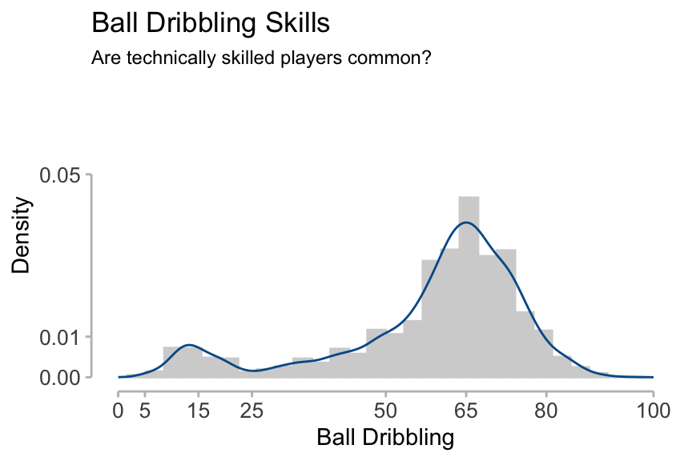

```r
... + geom_density(color = "#005b96", size = 0.5) + ...
```

The `color = "#005b96"` argument sets the color of the density curve to a shade of blue, while the `size = 0.5` argument specifies the thickness of the line.

### Function Reuse and Modularization

While you could achieve this by mechanically repeating the code three times and using the patchwork library to arrange the plots, it’s better to strive for modular code. Encapsulation principles are useful here. By encapsulating ggplot code within a function, you can easily apply the same plotting logic to different subsets of data corresponding to various player roles without rewriting the code each time.

```r
#---- 1. Encapsulate ggplot2 call. ----

create.histogram <- function(data, player_role, x_limit = 100) {
  data %>%
    select(role, skill_dribbling) %>%
    filter(role == player_role) %>%
    ggplot(aes(x = skill_dribbling)) +
    geom_histogram(aes(y = after_stat(density)), colour = "lightgrey", fill = "lightgrey") +
    geom_density(color = "#005b96", size = 0.5) +
    scale_x_continuous(limits = c(0, x_limit), breaks = c(0, 15, 25, 50, 65, 80, 100)) +
    scale_y_continuous(labels = scales::comma, limits = c(0, 0.1), breaks = c(0, 0.05, 0.1)) +
    labs(title = paste(player_role),
         subtitle = "Are technically skilled players common?",
         x = "Ball Dribbling",
         y = "Density") +
    theme(axis.text.x = element_text(size = 10),
          axis.text.y = element_text(size = 10),
          panel.border = element_blank(),
          axis.line = element_line(colour = "grey"),
          axis.ticks = element_line(color = "grey"),
          plot.subtitle=element_text(size=9)) +
    guides(y = guide_axis(cap = "both"),
           x = guide_axis(cap = "both"))
}
```

By encapsulating a ggplot call inside a custom function, we ensure that the plots are consistent in style and format, making them easier to interpret and present. Additionally, this approach forces us to standardize the input, allowing us to decide which parameters remain fixed and which ones can be adjusted.

Next, we analyze data for offensive, defensive, and midfielder players, saving each analysis as a ggplot object.

```r
#---- 2. # Create ball dribbling score histograms for offensive players and save each as a ggplot object. ----

hist.offense <- create.histogram(data, "Offense", 100)
hist.defense <- create.histogram(data, "Defense", 100)
hist.midfielders <- create.histogram(data, "Midfielders", 100)
hist.GK <- create.histogram(data, "GK", 100)
```

Finally, we use the patchwork library to arrange these plots into a grid.

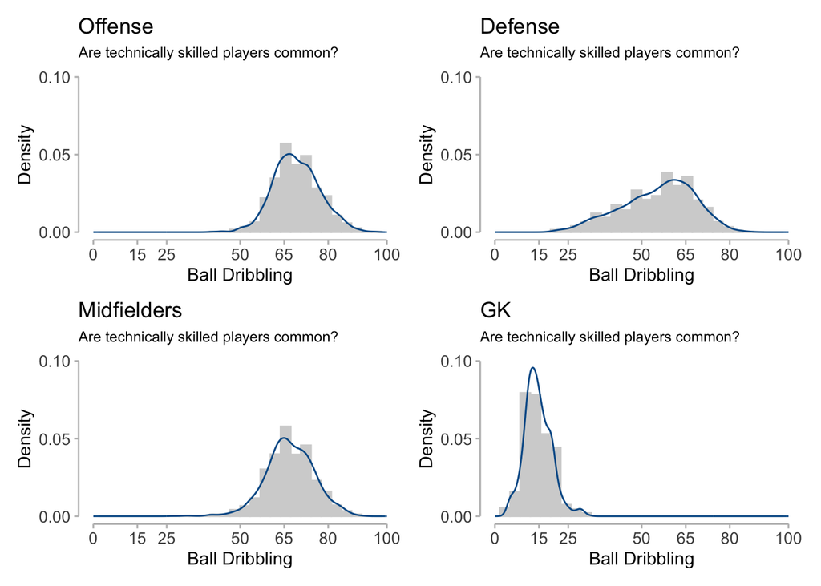

```r
library(patchwork)
hist.offense + hist.defense + hist.midfielders + hist.GK +
  plot_layout(ncol = 2, nrow = 2) # Implemented by patchworks.
```

### A Categorical and a Numerical Variable

To visualize the relationship between a numerical and a categorical variable, we can use side-by-side box plots. Although this visualization technique may be new to you, box plots essentially provide an alternative method to histograms. Assuming we still want to visualize `skill_dribbling` data for each player `role`, this technique will allow us to inspect data dispersion and, additionally, offer measures of positions (percentiles), which are useful for identifying outliers.

Creating a boxplot using ggplot geoms is straightforward process and follows the same principles as building other types of plots mentioned earlier. After selecting your data, simply apply `geom_boxplot()` with the appropriate settings.

```r
data %>%
  ggplot(aes(x = role, y = skill_dribbling , fill = role)) +
  geom_boxplot()
```

This code begins by piping the data into ggplot and mapping the `role` variable to the x-axis and `skill_dribbling` to the y-axis, with the `role` variable also determining the fill color of the boxes.

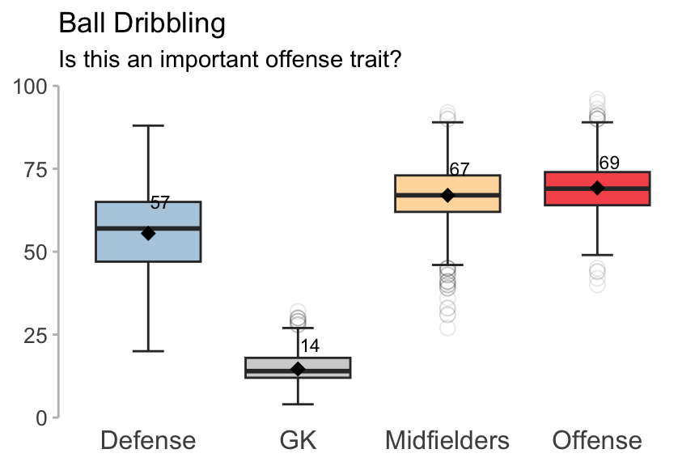

```r
data %>%
  ggplot(aes(x = role, y = skill_dribbling , fill = role)) +
  geom_boxplot(width = 0.7,
               outlier.shape = 1,
               outlier.fill = NA,
               outlier.size = 3,
               outlier.alpha = 0.1,
               outliers = TRUE, staplewidth = 0.3) +
  stat_summary(fun = mean,
               geom = "point",
               shape = 18, size = 3, color = "black", fill = "black") +
  stat_summary(fun = median, geom = "text",
               aes(label = round(after_stat(y), 1)),
               vjust = -1.5, hjust = -0.1, size = 3, color = "black") +
  scale_fill_manual(values=c("#b3cde0", "lightgrey", "#ffdbac","#f65858" )) +
  labs(title = "Ball Dribbling",
       subtitle = "Is this an important offense trait?") +
  theme(legend.position="none",
        axis.text.x = element_text(size = 12),
        axis.text.y = element_text(size = 10),
        axis.title.y = element_blank(),
        axis.title.x = element_blank(),
        panel.border = element_blank(),
        axis.ticks.x = element_blank(),
        axis.line.x = element_blank(),
        axis.line = element_line(colour = "grey"),
        axis.ticks = element_line(color = "grey")) +
  guides(y = guide_axis(cap = "both"))
```

### Footnotes

[^1]: James, Gareth, Daniela Witten, Trevor Hastie, and Robert Tibshirani. 2021. *An Introduction to Statistical Learning: With Applications in R*. 2nd ed. New York: Springer.
[^2]: Wickham, Hadley. 2019. *Advanced R*. 2nd ed. Boca Raton, FL: CRC Press.
[^3]: An alternative to a vertically stacked bar plot is the `geom_col(position = "dodge")` function, which creates a bar plot where bars for different groups are placed side by side. This approach is useful for comparing the counts or values of different categories within each group, making it easier to see the differences between them.
[^4]: The `after_stat()` function was introduced as a replacement for older approaches in ggplot2. It allows for the evaluation of aesthetics after statistical transformations have been applied to the data. This function replaced the older methods of using either `stat()`, such as `stat(density)`, or surrounding variable names with double dots, like `..density..`.